# Risk Factor Analysis

## Outcome Variable

**Outcome Variable:** ever_swasted

## Predictor Variables

**Intervention Variable:** single

**Adjustment Set:**

unadjusted

## Stratifying Variables

The analysis was stratified on these variable(s):

- agecat
- studyid
- country

## Data Summary

| agecat | studyid | country | single | ever_swasted | n_cell | n |
| --- | --- | --- | --- | --- | --- | --- |
| 0-24 months | COHORTS | GUATEMALA | 0 | 0 | 1017 | 1197 |
| 0-24 months | COHORTS | GUATEMALA | 0 | 1 | 82 | 1197 |
| 0-24 months | COHORTS | GUATEMALA | 1 | 0 | 90 | 1197 |
| 0-24 months | COHORTS | GUATEMALA | 1 | 1 | 8 | 1197 |
| 0-24 months | COHORTS | INDIA | 0 | 0 | 4814 | 5376 |
| 0-24 months | COHORTS | INDIA | 0 | 1 | 553 | 5376 |
| 0-24 months | COHORTS | INDIA | 1 | 0 | 7 | 5376 |
| 0-24 months | COHORTS | INDIA | 1 | 1 | 2 | 5376 |
| 0-24 months | COHORTS | PHILIPPINES | 0 | 0 | 2571 | 3005 |
| 0-24 months | COHORTS | PHILIPPINES | 0 | 1 | 360 | 3005 |
| 0-24 months | COHORTS | PHILIPPINES | 1 | 0 | 54 | 3005 |
| 0-24 months | COHORTS | PHILIPPINES | 1 | 1 | 20 | 3005 |
| 0-24 months | Guatemala BSC | GUATEMALA | 0 | 0 | 250 | 282 |
| 0-24 months | Guatemala BSC | GUATEMALA | 0 | 1 | 2 | 282 |
| 0-24 months | Guatemala BSC | GUATEMALA | 1 | 0 | 29 | 282 |
| 0-24 months | Guatemala BSC | GUATEMALA | 1 | 1 | 1 | 282 |
| 0-24 months | MAL-ED | BANGLADESH | 0 | 0 | 242 | 263 |
| 0-24 months | MAL-ED | BANGLADESH | 0 | 1 | 21 | 263 |
| 0-24 months | MAL-ED | BANGLADESH | 1 | 0 | 0 | 263 |
| 0-24 months | MAL-ED | BANGLADESH | 1 | 1 | 0 | 263 |
| 0-24 months | MAL-ED | BRAZIL | 0 | 0 | 194 | 233 |
| 0-24 months | MAL-ED | BRAZIL | 0 | 1 | 3 | 233 |
| 0-24 months | MAL-ED | BRAZIL | 1 | 0 | 35 | 233 |
| 0-24 months | MAL-ED | BRAZIL | 1 | 1 | 1 | 233 |
| 0-24 months | MAL-ED | INDIA | 0 | 0 | 223 | 249 |
| 0-24 months | MAL-ED | INDIA | 0 | 1 | 26 | 249 |
| 0-24 months | MAL-ED | INDIA | 1 | 0 | 0 | 249 |
| 0-24 months | MAL-ED | INDIA | 1 | 1 | 0 | 249 |
| 0-24 months | MAL-ED | NEPAL | 0 | 0 | 231 | 240 |
| 0-24 months | MAL-ED | NEPAL | 0 | 1 | 9 | 240 |

[output cut: 138 more lines]

The following strata were considered:

- agecat: 0-24 months, studyid: COHORTS, country: GUATEMALA
- agecat: 0-24 months, studyid: COHORTS, country: INDIA
- agecat: 0-24 months, studyid: COHORTS, country: PHILIPPINES
- agecat: 0-24 months, studyid: Guatemala BSC, country: GUATEMALA
- agecat: 0-24 months, studyid: MAL-ED, country: BANGLADESH
- agecat: 0-24 months, studyid: MAL-ED, country: BRAZIL
- agecat: 0-24 months, studyid: MAL-ED, country: INDIA
- agecat: 0-24 months, studyid: MAL-ED, country: NEPAL
- agecat: 0-24 months, studyid: MAL-ED, country: PERU
- agecat: 0-24 months, studyid: MAL-ED, country: SOUTH AFRICA
- agecat: 0-24 months, studyid: MAL-ED, country: TANZANIA, UNITED REPUBLIC OF
- agecat: 0-24 months, studyid: PROBIT, country: BELARUS
- agecat: 0-24 months, studyid: TanzaniaChild2, country: TANZANIA, UNITED REPUBLIC OF
- agecat: 0-24 months, studyid: ZVITAMBO, country: ZIMBABWE
- agecat: 0-6 months, studyid: COHORTS, country: GUATEMALA
- agecat: 0-6 months, studyid: COHORTS, country: INDIA
- agecat: 0-6 months, studyid: COHORTS, country: PHILIPPINES
- agecat: 0-6 months, studyid: Guatemala BSC, country: GUATEMALA
- agecat: 0-6 months, studyid: MAL-ED, country: BANGLADESH
- agecat: 0-6 months, studyid: MAL-ED, country: BRAZIL
- agecat: 0-6 months, studyid: MAL-ED, country: INDIA
- agecat: 0-6 months, studyid: MAL-ED, country: NEPAL
- agecat: 0-6 months, studyid: MAL-ED, country: PERU
- agecat: 0-6 months, studyid: MAL-ED, country: SOUTH AFRICA
- agecat: 0-6 months, studyid: MAL-ED, country: TANZANIA, UNITED REPUBLIC OF
- agecat: 0-6 months, studyid: PROBIT, country: BELARUS
- agecat: 0-6 months, studyid: TanzaniaChild2, country: TANZANIA, UNITED REPUBLIC OF
- agecat: 0-6 months, studyid: ZVITAMBO, country: ZIMBABWE
- agecat: 6-24 months, studyid: COHORTS, country: GUATEMALA
- agecat: 6-24 months, studyid: COHORTS, country: INDIA
- agecat: 6-24 months, studyid: COHORTS, country: PHILIPPINES
- agecat: 6-24 months, studyid: Guatemala BSC, country: GUATEMALA
- agecat: 6-24 months, studyid: MAL-ED, country: BANGLADESH
- agecat: 6-24 months, studyid: MAL-ED, country: BRAZIL
- agecat: 6-24 months, studyid: MAL-ED, country: INDIA
- agecat: 6-24 months, studyid: MAL-ED, country: NEPAL
- agecat: 6-24 months, studyid: MAL-ED, country: PERU
- agecat: 6-24 months, studyid: MAL-ED, country: SOUTH AFRICA
- agecat: 6-24 months, studyid: MAL-ED, country: TANZANIA, UNITED REPUBLIC OF
- agecat: 6-24 months, studyid: PROBIT, country: BELARUS
- agecat: 6-24 months, studyid: TanzaniaChild2, country: TANZANIA, UNITED REPUBLIC OF
- agecat: 6-24 months, studyid: ZVITAMBO, country: ZIMBABWE

### Dropped Strata

Some strata were dropped due to rare outcomes:

- agecat: 0-24 months, studyid: COHORTS, country: INDIA
- agecat: 0-24 months, studyid: Guatemala BSC, country: GUATEMALA
- agecat: 0-24 months, studyid: MAL-ED, country: BANGLADESH
- agecat: 0-24 months, studyid: MAL-ED, country: BRAZIL
- agecat: 0-24 months, studyid: MAL-ED, country: INDIA
- agecat: 0-24 months, studyid: MAL-ED, country: NEPAL
- agecat: 0-24 months, studyid: MAL-ED, country: PERU
- agecat: 0-24 months, studyid: MAL-ED, country: TANZANIA, UNITED REPUBLIC OF
- agecat: 0-6 months, studyid: COHORTS, country: GUATEMALA
- agecat: 0-6 months, studyid: COHORTS, country: INDIA
- agecat: 0-6 months, studyid: Guatemala BSC, country: GUATEMALA
- agecat: 0-6 months, studyid: MAL-ED, country: BANGLADESH
- agecat: 0-6 months, studyid: MAL-ED, country: BRAZIL
- agecat: 0-6 months, studyid: MAL-ED, country: INDIA
- agecat: 0-6 months, studyid: MAL-ED, country: NEPAL
- agecat: 0-6 months, studyid: MAL-ED, country: PERU
- agecat: 0-6 months, studyid: MAL-ED, country: SOUTH AFRICA
- agecat: 0-6 months, studyid: MAL-ED, country: TANZANIA, UNITED REPUBLIC OF
- agecat: 6-24 months, studyid: COHORTS, country: INDIA
- agecat: 6-24 months, studyid: Guatemala BSC, country: GUATEMALA
- agecat: 6-24 months, studyid: MAL-ED, country: BANGLADESH
- agecat: 6-24 months, studyid: MAL-ED, country: BRAZIL
- agecat: 6-24 months, studyid: MAL-ED, country: INDIA
- agecat: 6-24 months, studyid: MAL-ED, country: NEPAL
- agecat: 6-24 months, studyid: MAL-ED, country: PERU
- agecat: 6-24 months, studyid: MAL-ED, country: SOUTH AFRICA
- agecat: 6-24 months, studyid: MAL-ED, country: TANZANIA, UNITED REPUBLIC OF
- agecat: 6-24 months, studyid: PROBIT, country: BELARUS

## Methods Detail

We’re interested in the causal parameters $E[Y_a]$ for all values of $a \in \mathcal{A}$. These parameters represent the mean outcome if, possibly contrary to fact, we intervened to set all units to have $A=a$. Under the randomization and positivity assumptions, these are identified by the statistical parameters $\psi_a=E_W[E_{Y|A,W}(Y|A=a,W)]$. In addition, we’re interested in the mean of $Y$, $E[Y]$ under no intervention (the observed mean). We will estimate these parameters by using SuperLearner to fit the relevant likelihood factors – $E_{Y|A,W}(Y|A=a,W)$ and $p(A=a|W)$, and then updating our likelihood fit using a joint TMLE.

For unadjusted analyses ($W=\{\}$), initial likelihoods were estimated using Lrnr_glm to estimate the simple $E(Y|A)$ and Lrnr_mean to estimate $p(A)$. For adjusted analyses, a small library containing Lrnr_glmnet, Lrnr_xgboost, and Lrnr_mean was used.

Having estimated these parameters, we will then use the delta method to estimate relative risks and attributable risks relative to a prespecified baseline level of $A$.

# Results Detail

## Results Plots

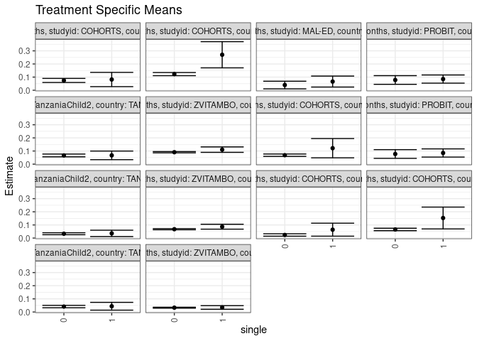

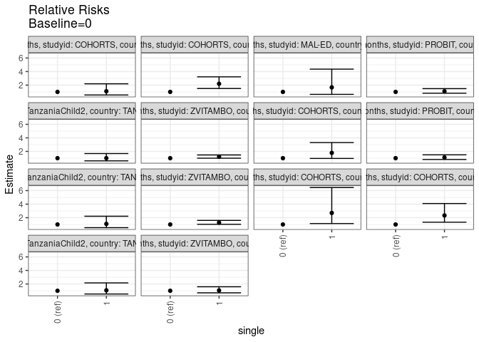

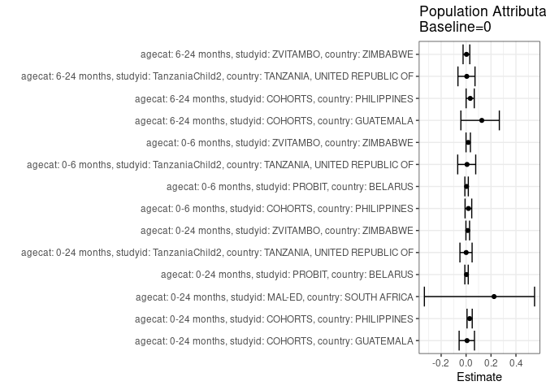

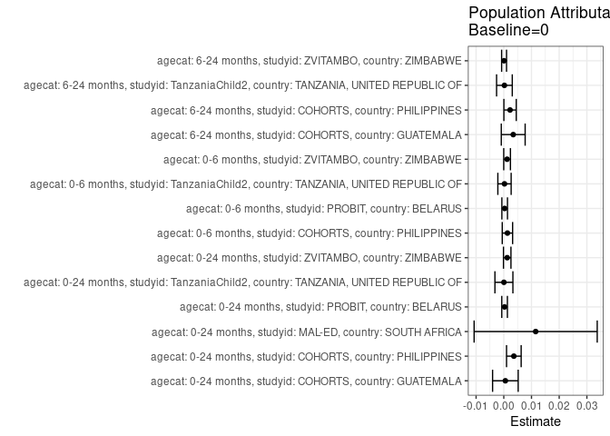

## Results Table

### Parameter: TSM

| agecat | studyid | country | intervention_level | baseline_level | estimate | ci_lower | ci_upper |
| --- | --- | --- | --- | --- | --- | --- | --- |
| 0-24 months | COHORTS | GUATEMALA | 0 | NA | 0.0746133 | 0.0590715 | 0.0901551 |
| 0-24 months | COHORTS | GUATEMALA | 1 | NA | 0.0816327 | 0.0274005 | 0.1358648 |
| 0-24 months | COHORTS | PHILIPPINES | 0 | NA | 0.1228250 | 0.1109354 | 0.1347145 |
| 0-24 months | COHORTS | PHILIPPINES | 1 | NA | 0.2702703 | 0.1705848 | 0.3699557 |
| 0-24 months | MAL-ED | SOUTH AFRICA | 0 | NA | 0.0397727 | 0.0108547 | 0.0686907 |
| 0-24 months | MAL-ED | SOUTH AFRICA | 1 | NA | 0.0661765 | 0.0243299 | 0.1080230 |
| 0-24 months | PROBIT | BELARUS | 0 | NA | 0.0781240 | 0.0450774 | 0.1111706 |
| 0-24 months | PROBIT | BELARUS | 1 | NA | 0.0851371 | 0.0540467 | 0.1162275 |
| 0-24 months | TanzaniaChild2 | TANZANIA, UNITED REPUBLIC OF | 0 | NA | 0.0664807 | 0.0559507 | 0.0770107 |
| 0-24 months | TanzaniaChild2 | TANZANIA, UNITED REPUBLIC OF | 1 | NA | 0.0669643 | 0.0342237 | 0.0997049 |
| 0-24 months | ZVITAMBO | ZIMBABWE | 0 | NA | 0.0909161 | 0.0859762 | 0.0958559 |
| 0-24 months | ZVITAMBO | ZIMBABWE | 1 | NA | 0.1104784 | 0.0897420 | 0.1312148 |
| 0-6 months | COHORTS | PHILIPPINES | 0 | NA | 0.0682594 | 0.0591229 | 0.0773959 |
| 0-6 months | COHORTS | PHILIPPINES | 1 | NA | 0.1216216 | 0.0482307 | 0.1950126 |
| 0-6 months | PROBIT | BELARUS | 0 | NA | 0.0773979 | 0.0443066 | 0.1104891 |
| 0-6 months | PROBIT | BELARUS | 1 | NA | 0.0851371 | 0.0540406 | 0.1162335 |
| 0-6 months | TanzaniaChild2 | TANZANIA, UNITED REPUBLIC OF | 0 | NA | 0.0330079 | 0.0254563 | 0.0405595 |
| 0-6 months | TanzaniaChild2 | TANZANIA, UNITED REPUBLIC OF | 1 | NA | 0.0357143 | 0.0114068 | 0.0600217 |
| 0-6 months | ZVITAMBO | ZIMBABWE | 0 | NA | 0.0675947 | 0.0632674 | 0.0719221 |
| 0-6 months | ZVITAMBO | ZIMBABWE | 1 | NA | 0.0865052 | 0.0677928 | 0.1052175 |
| 6-24 months | COHORTS | GUATEMALA | 0 | NA | 0.0235988 | 0.0142654 | 0.0329323 |
| 6-24 months | COHORTS | GUATEMALA | 1 | NA | 0.0638298 | 0.0143909 | 0.1132687 |
| 6-24 months | COHORTS | PHILIPPINES | 0 | NA | 0.0654828 | 0.0561554 | 0.0748102 |
| 6-24 months | COHORTS | PHILIPPINES | 1 | NA | 0.1527778 | 0.0696610 | 0.2358946 |
| 6-24 months | TanzaniaChild2 | TANZANIA, UNITED REPUBLIC OF | 0 | NA | 0.0412088 | 0.0320744 | 0.0503431 |
| 6-24 months | TanzaniaChild2 | TANZANIA, UNITED REPUBLIC OF | 1 | NA | 0.0437158 | 0.0140850 | 0.0733467 |
| 6-24 months | ZVITAMBO | ZIMBABWE | 0 | NA | 0.0327625 | 0.0292912 | 0.0362339 |
| 6-24 months | ZVITAMBO | ZIMBABWE | 1 | NA | 0.0344311 | 0.0206035 | 0.0482588 |

### Parameter: E(Y)

| agecat | studyid | country | intervention_level | baseline_level | estimate | ci_lower | ci_upper |
| --- | --- | --- | --- | --- | --- | --- | --- |
| 0-24 months | COHORTS | GUATEMALA | NA | NA | 0.0751880 | 0.0602434 | 0.0901325 |
| 0-24 months | COHORTS | PHILIPPINES | NA | NA | 0.1264559 | 0.1145706 | 0.1383412 |
| 0-24 months | MAL-ED | SOUTH AFRICA | NA | NA | 0.0512821 | 0.0267678 | 0.0757963 |
| 0-24 months | PROBIT | BELARUS | NA | NA | 0.0784116 | 0.0458146 | 0.1110087 |
| 0-24 months | TanzaniaChild2 | TANZANIA, UNITED REPUBLIC OF | NA | NA | 0.0665263 | 0.0565020 | 0.0765506 |
| 0-24 months | ZVITAMBO | ZIMBABWE | NA | NA | 0.0921526 | 0.0873423 | 0.0969629 |
| 0-6 months | COHORTS | PHILIPPINES | NA | NA | 0.0695739 | 0.0604740 | 0.0786738 |
| 0-6 months | PROBIT | BELARUS | NA | NA | 0.0777153 | 0.0450748 | 0.1103558 |
| 0-6 months | TanzaniaChild2 | TANZANIA, UNITED REPUBLIC OF | NA | NA | 0.0332632 | 0.0260497 | 0.0404766 |
| 0-6 months | ZVITAMBO | ZIMBABWE | NA | NA | 0.0687831 | 0.0645599 | 0.0730062 |
| 6-24 months | COHORTS | GUATEMALA | NA | NA | 0.0270027 | 0.0174671 | 0.0365383 |
| 6-24 months | COHORTS | PHILIPPINES | NA | NA | 0.0677477 | 0.0583957 | 0.0770998 |
| 6-24 months | TanzaniaChild2 | TANZANIA, UNITED REPUBLIC OF | NA | NA | 0.0414378 | 0.0327076 | 0.0501681 |
| 6-24 months | ZVITAMBO | ZIMBABWE | NA | NA | 0.0328660 | 0.0294989 | 0.0362331 |

### Parameter: RR

| agecat | studyid | country | intervention_level | baseline_level | estimate | ci_lower | ci_upper |
| --- | --- | --- | --- | --- | --- | --- | --- |
| 0-24 months | COHORTS | GUATEMALA | 0 | 0 | 1.000000 | 1.0000000 | 1.000000 |
| 0-24 months | COHORTS | GUATEMALA | 1 | 0 | 1.094077 | 0.5453529 | 2.194916 |
| 0-24 months | COHORTS | PHILIPPINES | 0 | 0 | 1.000000 | 1.0000000 | 1.000000 |
| 0-24 months | COHORTS | PHILIPPINES | 1 | 0 | 2.200451 | 1.5028070 | 3.221959 |
| 0-24 months | MAL-ED | SOUTH AFRICA | 0 | 0 | 1.000000 | 1.0000000 | 1.000000 |
| 0-24 months | MAL-ED | SOUTH AFRICA | 1 | 0 | 1.663865 | 0.6347971 | 4.361155 |
| 0-24 months | PROBIT | BELARUS | 0 | 0 | 1.000000 | 1.0000000 | 1.000000 |
| 0-24 months | PROBIT | BELARUS | 1 | 0 | 1.089768 | 0.8021415 | 1.480530 |
| 0-24 months | TanzaniaChild2 | TANZANIA, UNITED REPUBLIC OF | 0 | 0 | 1.000000 | 1.0000000 | 1.000000 |
| 0-24 months | TanzaniaChild2 | TANZANIA, UNITED REPUBLIC OF | 1 | 0 | 1.007274 | 0.6024838 | 1.684030 |
| 0-24 months | ZVITAMBO | ZIMBABWE | 0 | 0 | 1.000000 | 1.0000000 | 1.000000 |
| 0-24 months | ZVITAMBO | ZIMBABWE | 1 | 0 | 1.215169 | 0.9994804 | 1.477402 |
| 0-6 months | COHORTS | PHILIPPINES | 0 | 0 | 1.000000 | 1.0000000 | 1.000000 |
| 0-6 months | COHORTS | PHILIPPINES | 1 | 0 | 1.781757 | 0.9603060 | 3.305881 |
| 0-6 months | PROBIT | BELARUS | 0 | 0 | 1.000000 | 1.0000000 | 1.000000 |
| 0-6 months | PROBIT | BELARUS | 1 | 0 | 1.099993 | 0.8080955 | 1.497328 |
| 0-6 months | TanzaniaChild2 | TANZANIA, UNITED REPUBLIC OF | 0 | 0 | 1.000000 | 1.0000000 | 1.000000 |
| 0-6 months | TanzaniaChild2 | TANZANIA, UNITED REPUBLIC OF | 1 | 0 | 1.081992 | 0.5276998 | 2.218509 |
| 0-6 months | ZVITAMBO | ZIMBABWE | 0 | 0 | 1.000000 | 1.0000000 | 1.000000 |
| 0-6 months | ZVITAMBO | ZIMBABWE | 1 | 0 | 1.279762 | 1.0213087 | 1.603620 |
| 6-24 months | COHORTS | GUATEMALA | 0 | 0 | 1.000000 | 1.0000000 | 1.000000 |
| 6-24 months | COHORTS | GUATEMALA | 1 | 0 | 2.704787 | 1.1335391 | 6.454011 |
| 6-24 months | COHORTS | PHILIPPINES | 0 | 0 | 1.000000 | 1.0000000 | 1.000000 |
| 6-24 months | COHORTS | PHILIPPINES | 1 | 0 | 2.333098 | 1.3295250 | 4.094203 |
| 6-24 months | TanzaniaChild2 | TANZANIA, UNITED REPUBLIC OF | 0 | 0 | 1.000000 | 1.0000000 | 1.000000 |
| 6-24 months | TanzaniaChild2 | TANZANIA, UNITED REPUBLIC OF | 1 | 0 | 1.060838 | 0.5199252 | 2.164498 |
| 6-24 months | ZVITAMBO | ZIMBABWE | 0 | 0 | 1.000000 | 1.0000000 | 1.000000 |
| 6-24 months | ZVITAMBO | ZIMBABWE | 1 | 0 | 1.050930 | 0.6937326 | 1.592045 |

### Parameter: PAR

| agecat | studyid | country | intervention_level | baseline_level | estimate | ci_lower | ci_upper |
| --- | --- | --- | --- | --- | --- | --- | --- |
| 0-24 months | COHORTS | GUATEMALA | 0 | NA | 0.0005747 | -0.0040454 | 0.0051948 |
| 0-24 months | COHORTS | PHILIPPINES | 0 | NA | 0.0036309 | 0.0009915 | 0.0062704 |
| 0-24 months | MAL-ED | SOUTH AFRICA | 0 | NA | 0.0115093 | -0.0107109 | 0.0337295 |
| 0-24 months | PROBIT | BELARUS | 0 | NA | 0.0002876 | -0.0007268 | 0.0013021 |
| 0-24 months | TanzaniaChild2 | TANZANIA, UNITED REPUBLIC OF | 0 | NA | 0.0000456 | -0.0031981 | 0.0032893 |
| 0-24 months | ZVITAMBO | ZIMBABWE | 0 | NA | 0.0012366 | -0.0001132 | 0.0025863 |
| 0-6 months | COHORTS | PHILIPPINES | 0 | NA | 0.0013145 | -0.0005579 | 0.0031870 |
| 0-6 months | PROBIT | BELARUS | 0 | NA | 0.0003174 | -0.0006967 | 0.0013316 |
| 0-6 months | TanzaniaChild2 | TANZANIA, UNITED REPUBLIC OF | 0 | NA | 0.0002553 | -0.0021456 | 0.0026561 |
| 0-6 months | ZVITAMBO | ZIMBABWE | 0 | NA | 0.0011883 | -0.0000210 | 0.0023977 |
| 6-24 months | COHORTS | GUATEMALA | 0 | NA | 0.0034039 | -0.0009036 | 0.0077114 |
| 6-24 months | COHORTS | PHILIPPINES | 0 | NA | 0.0022650 | 0.0000343 | 0.0044956 |
| 6-24 months | TanzaniaChild2 | TANZANIA, UNITED REPUBLIC OF | 0 | NA | 0.0002291 | -0.0026040 | 0.0030621 |
| 6-24 months | ZVITAMBO | ZIMBABWE | 0 | NA | 0.0001035 | -0.0007807 | 0.0009877 |

### Parameter: PAF

| agecat | studyid | country | intervention_level | baseline_level | estimate | ci_lower | ci_upper |
| --- | --- | --- | --- | --- | --- | --- | --- |
| 0-24 months | COHORTS | GUATEMALA | 0 | NA | 0.0076433 | -0.0557292 | 0.0672117 |
| 0-24 months | COHORTS | PHILIPPINES | 0 | NA | 0.0287130 | 0.0077382 | 0.0492444 |
| 0-24 months | MAL-ED | SOUTH AFRICA | 0 | NA | 0.2244318 | -0.3345633 | 0.5492863 |
| 0-24 months | PROBIT | BELARUS | 0 | NA | 0.0036680 | -0.0100897 | 0.0172382 |
| 0-24 months | TanzaniaChild2 | TANZANIA, UNITED REPUBLIC OF | 0 | NA | 0.0006856 | -0.0492821 | 0.0482738 |
| 0-24 months | ZVITAMBO | ZIMBABWE | 0 | NA | 0.0134185 | -0.0013243 | 0.0279442 |
| 0-6 months | COHORTS | PHILIPPINES | 0 | NA | 0.0188938 | -0.0082968 | 0.0453512 |
| 0-6 months | PROBIT | BELARUS | 0 | NA | 0.0040848 | -0.0098896 | 0.0178657 |
| 0-6 months | TanzaniaChild2 | TANZANIA, UNITED REPUBLIC OF | 0 | NA | 0.0076738 | -0.0671750 | 0.0772729 |
| 0-6 months | ZVITAMBO | ZIMBABWE | 0 | NA | 0.0172765 | -0.0004358 | 0.0346752 |
| 6-24 months | COHORTS | GUATEMALA | 0 | NA | 0.1260570 | -0.0417454 | 0.2668302 |
| 6-24 months | COHORTS | PHILIPPINES | 0 | NA | 0.0334321 | 0.0002274 | 0.0655341 |
| 6-24 months | TanzaniaChild2 | TANZANIA, UNITED REPUBLIC OF | 0 | NA | 0.0055276 | -0.0652363 | 0.0715907 |
| 6-24 months | ZVITAMBO | ZIMBABWE | 0 | NA | 0.0031486 | -0.0241193 | 0.0296905 |